# EU-ForDAM: damage graphs

Host killed per year and on average, NUTS occurrence, total damage — guilds and species

Published

October 30, 2026

**Data.** EU-ForDAM (`value1`, 2000–2022, 16 countries, 77 NUTS units) and the NUTS forest appendix (area and growing stock of spruce, pine, fir, oak, all conifers, all broadleaves). Reported damage only, no gap-filling. 0 = recorded, no damage; missing = left out.

**Units.** Borers = m³ of trees killed; defoliators = ha defoliated (not necessarily killed). The two are never added together.

**Guild vs species.** Guild graphs add up all codes of the guild (aggregate codes included). Species graphs show individual species only. Borers and defoliators are always shown on separate graphs.

**Host tree.** The host tree in the data file, as in the 2025 EU-ForDAM paper. Only two insects are changed, because with the file’s host their damage would exceed 100% of the host: *L. monacha* (file: spruce; used: spruce and pine) and *Melolontha* (file: oak; used: all forest). Larch, birch, elm and poplar are not separate in the forest appendix, so those species are divided by all conifers / all broadleaves. Check: damage never exceeds the host in any region and year (except Vienna, where the appendix gives 0 spruce but small spruce bark-beetle damage is reported).

## 1. Proportion of host plants killed per year

% of the host’s growing stock killed (borers) or forest area defoliated (defoliators) in each year = that year’s damage / host of the regions recording it.

### Guild

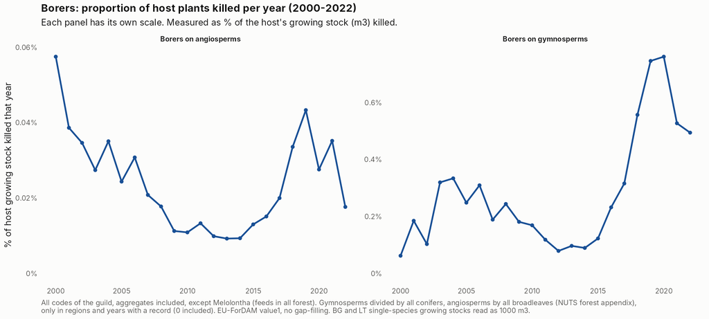

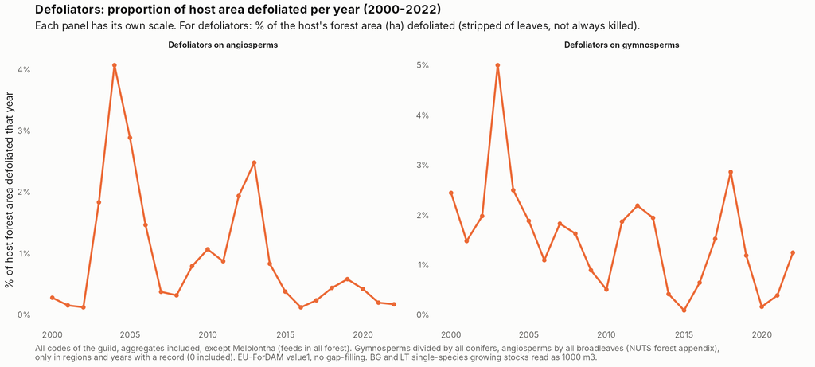

### Species

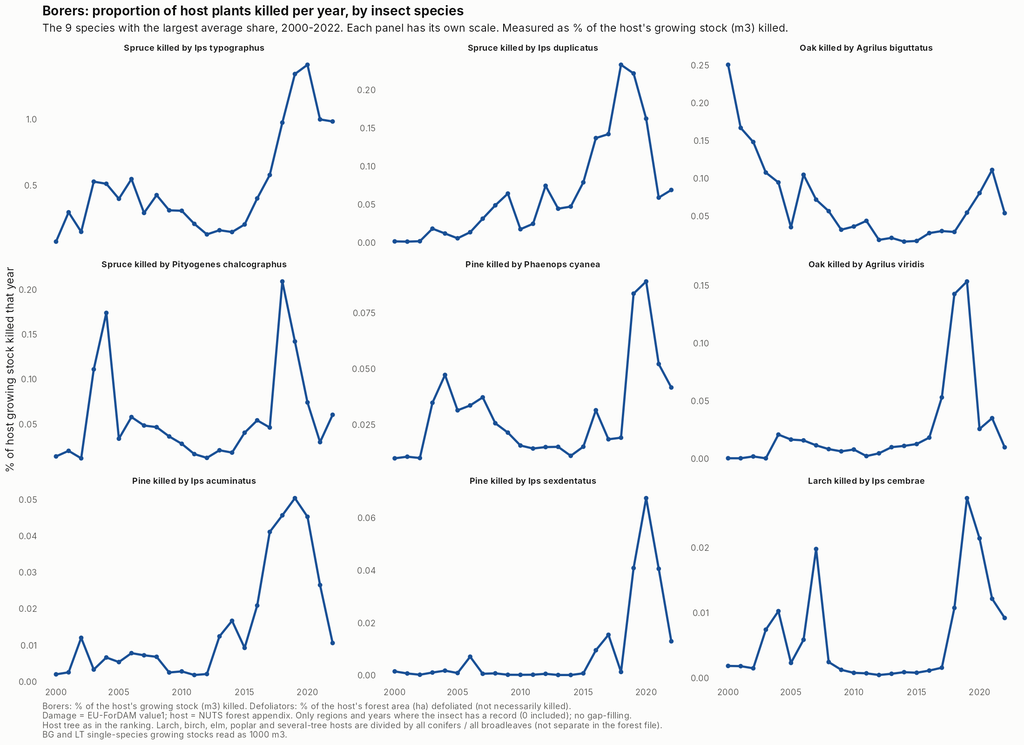

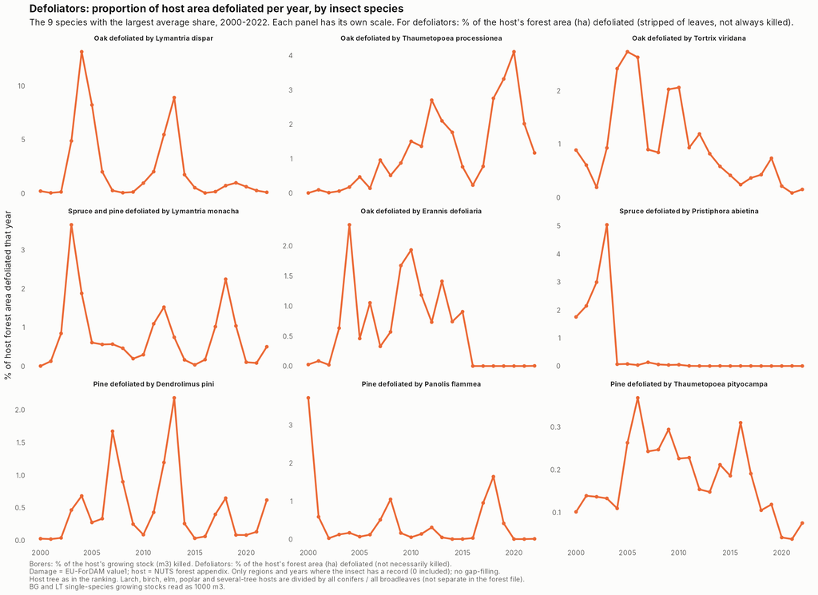

## 2. Proportion of host plants killed on average

Average per year = all recorded damage 2000–2022 / all host of the region-years where it is recorded.

### Guild

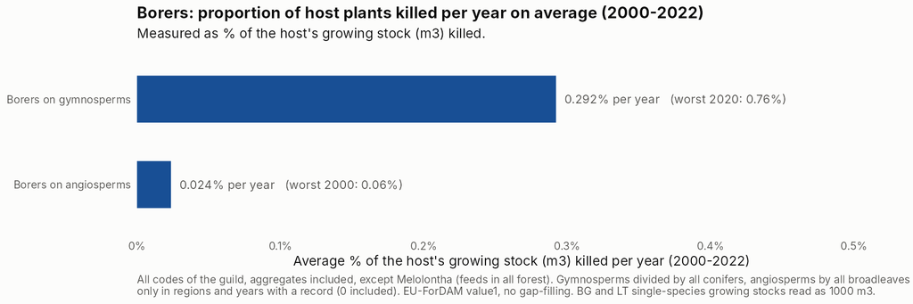

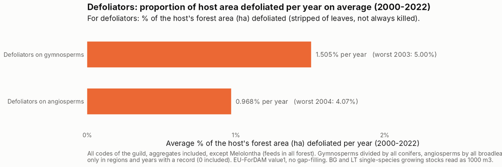

### Species

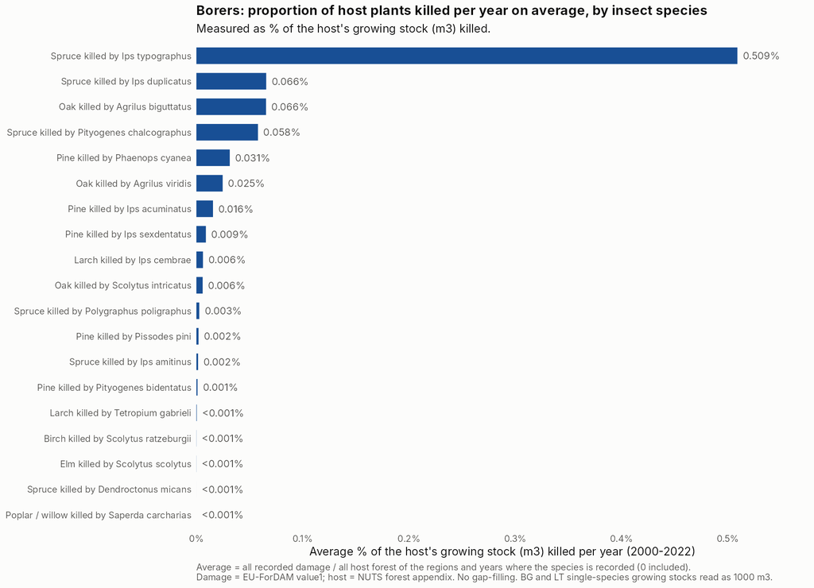

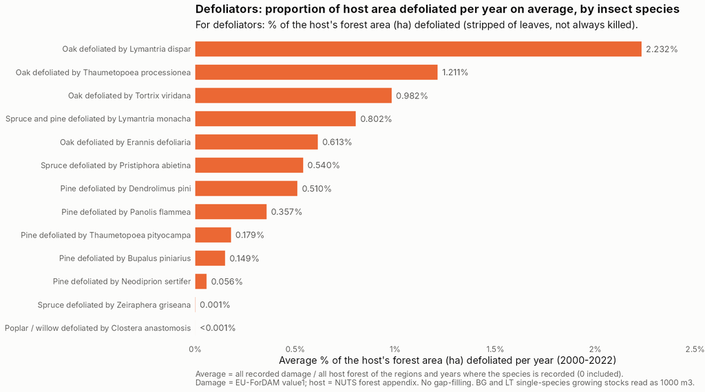

### Comparison with the 2025 paper

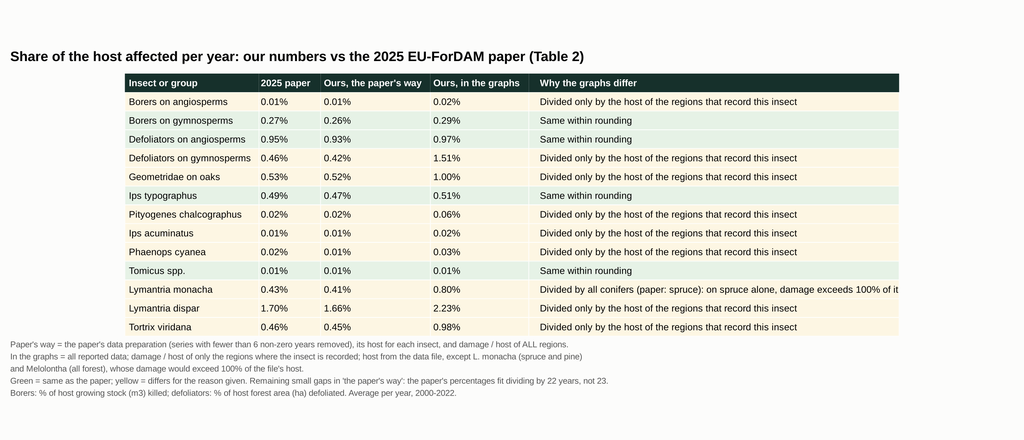

## 3. NUTS: where damage occurs

Number of NUTS units with damage (at least one year > 0). Note: 11 countries report as one unit, while Finland, Poland and Germany report 15–17 units each.

### Guild

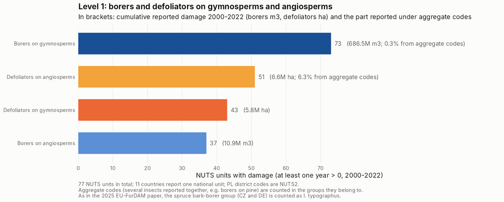

### Species

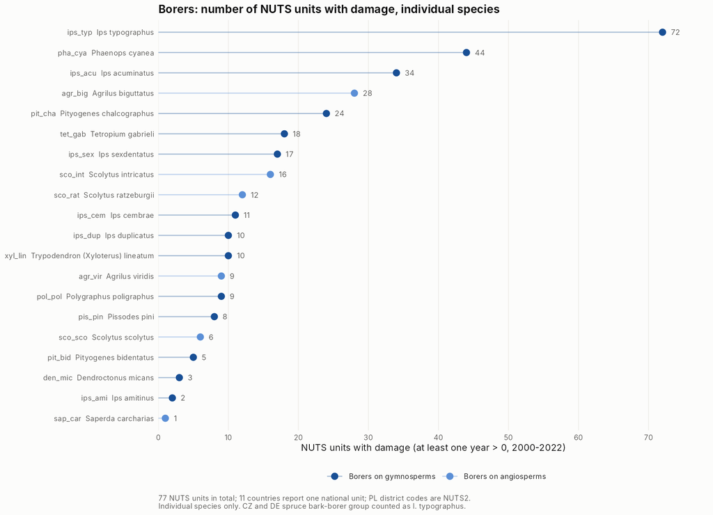

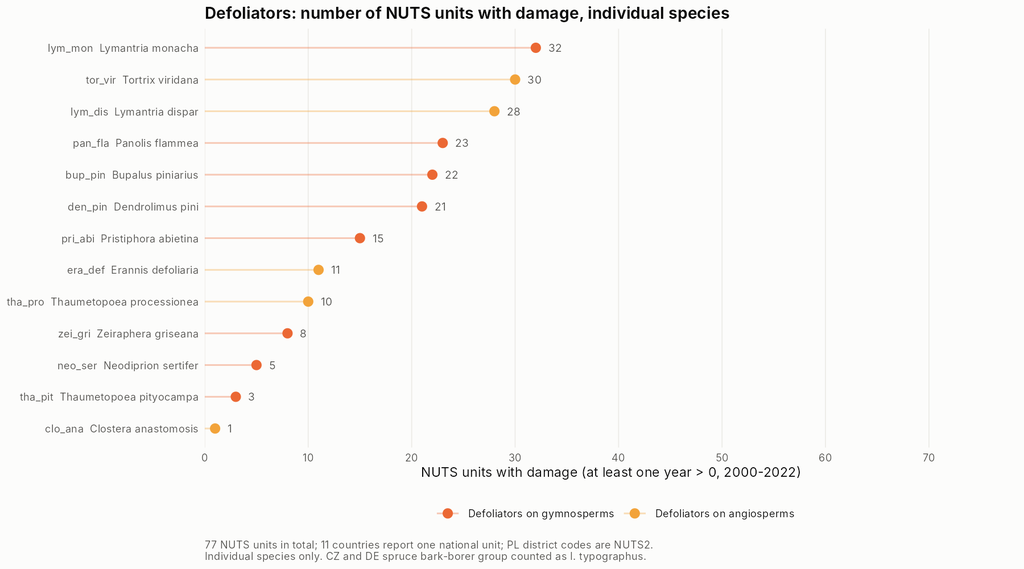

## 4. Total damage

All reported damage 2000–2022 added up.

### Guild

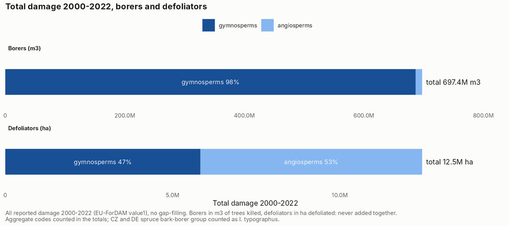

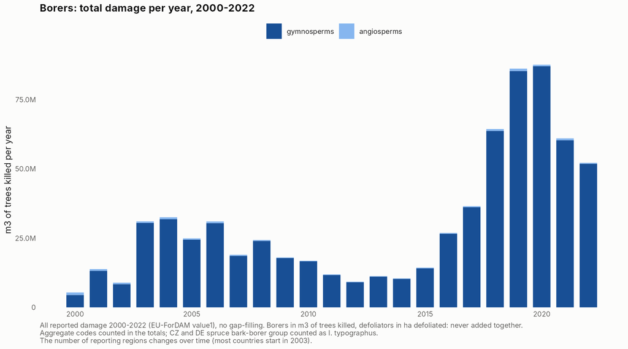

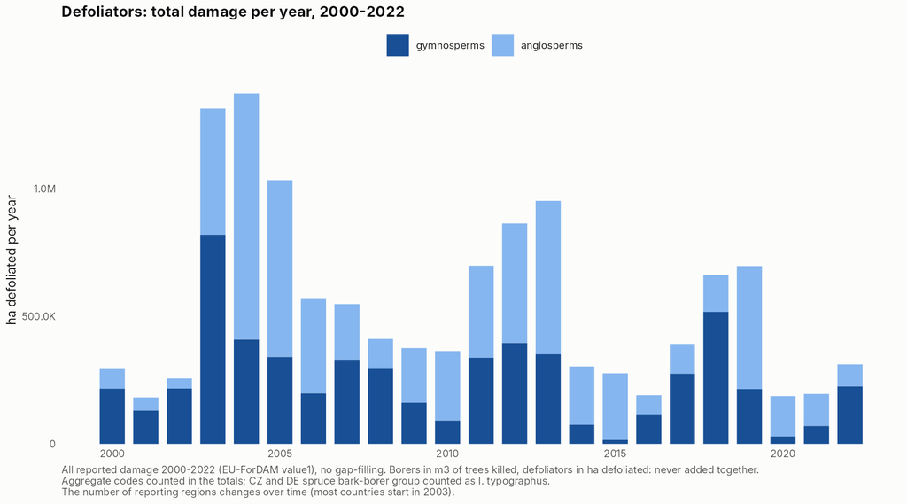

### Species

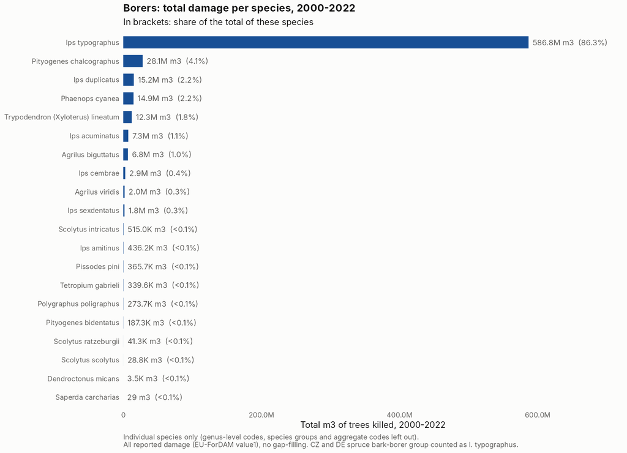

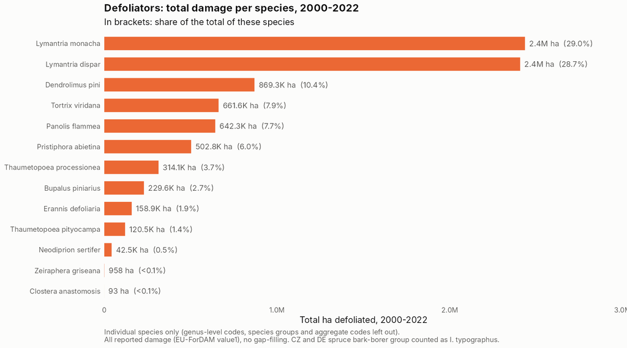

## 5. Usable pairs as time series

The 28 usable pairs from the correlation metrics (strong link that holds in every country checked), shown year by year. Only region-years where both insects are recorded; each region’s series compared with its own normal (0 = normal year, +1 = one standard deviation worse), then averaged over the regions. Lines moving together = the correlation r.

Pairs are grouped by what the two insects are (the paper’s level-1 groups): both borers on gymnosperms; a borer on gymnosperms with a borer on angiosperms; both borers on angiosperms; both defoliators on gymnosperms; a borer with a defoliator. Each panel names both insects with their guild and host tree.

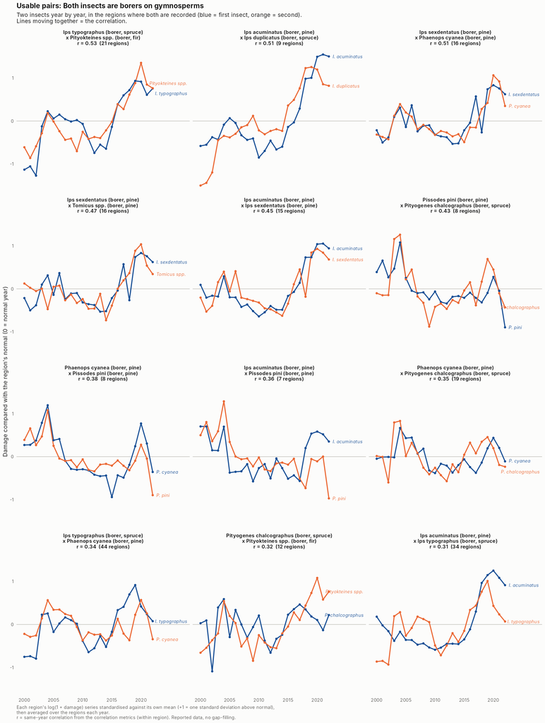

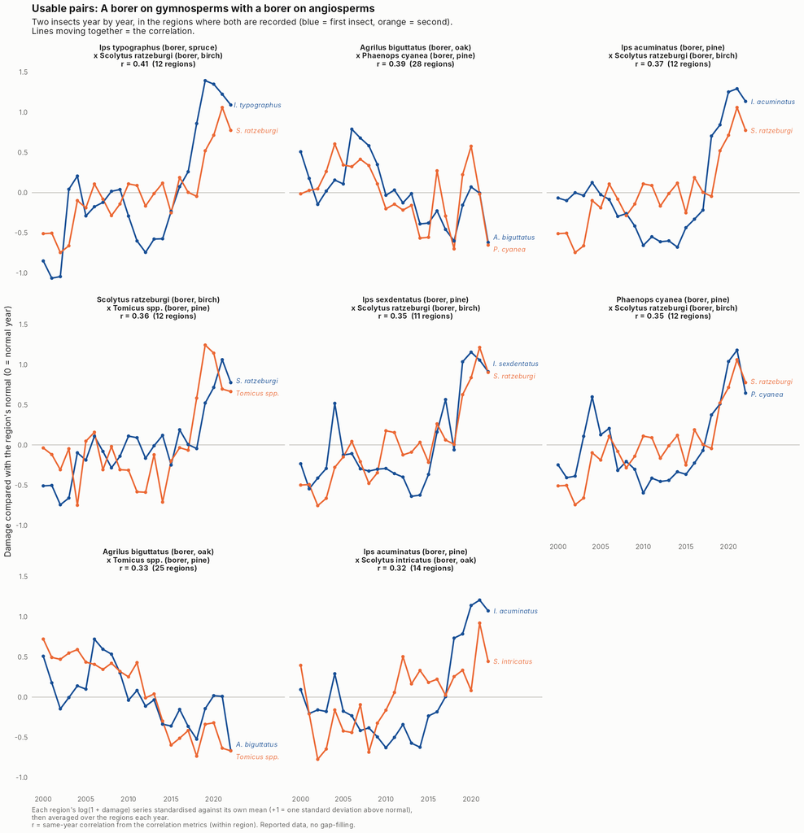

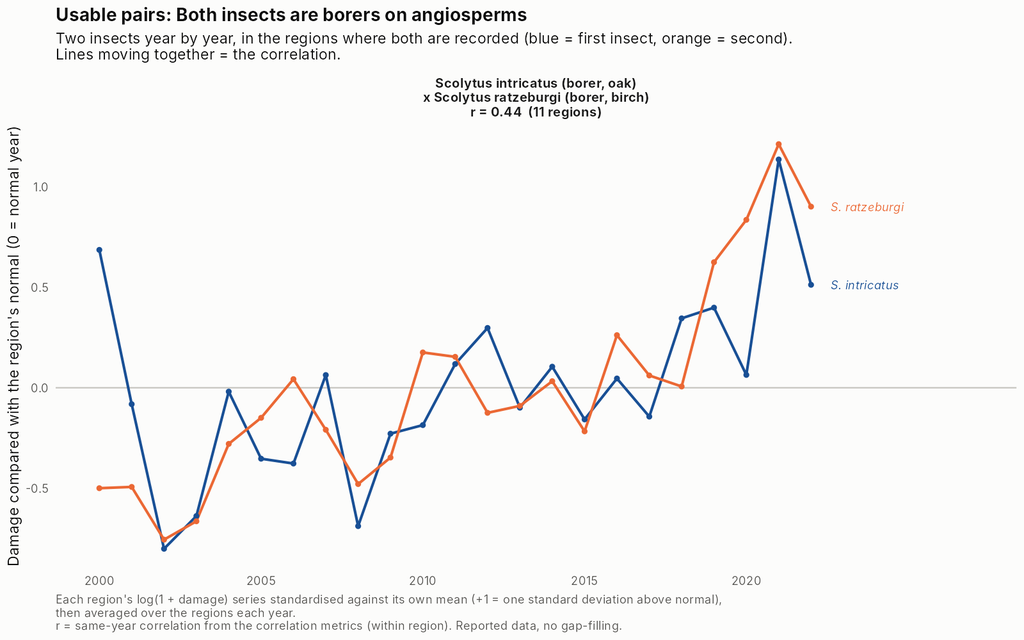

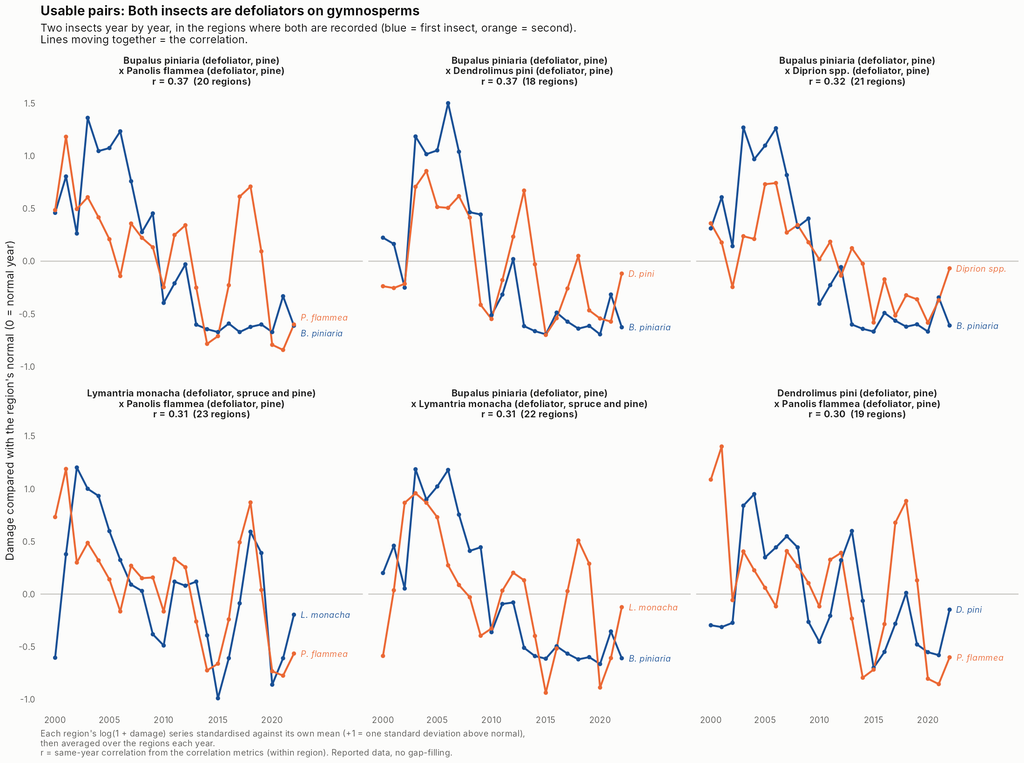

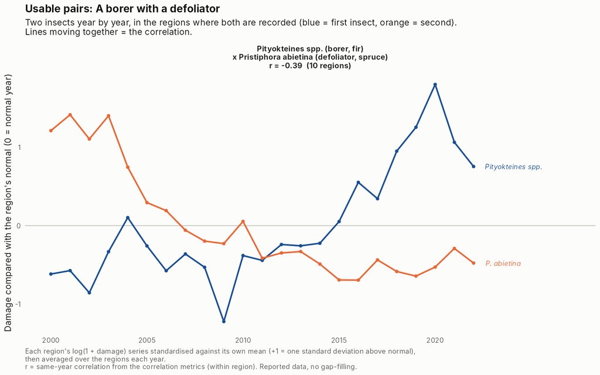

### The same pairs as scatterplots

One dot = one region in one year where both insects are recorded (x = first insect, y = second, each against the region’s own normal). Orange line = straight-line fit, band = its 95% range. This is exactly the data r is computed from; R² = r × r.

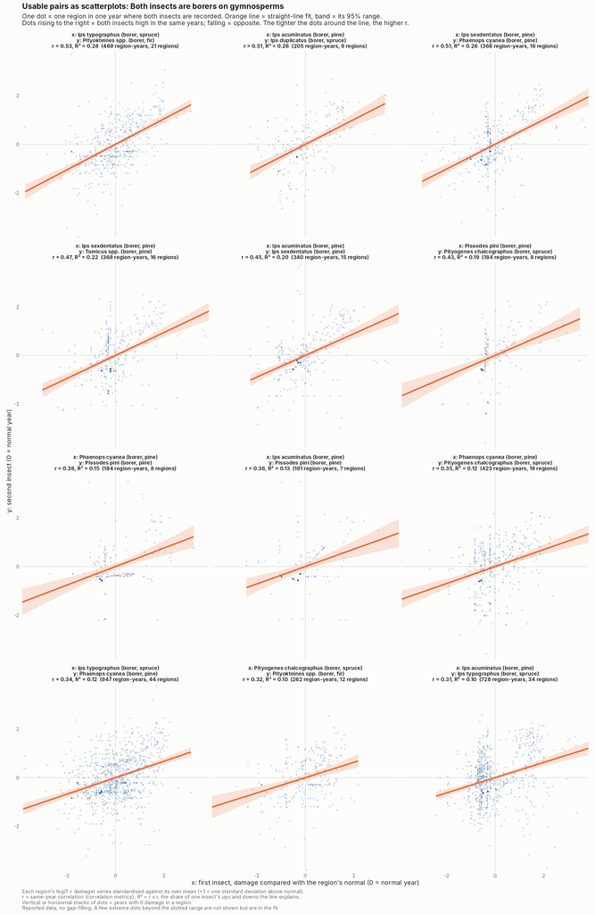

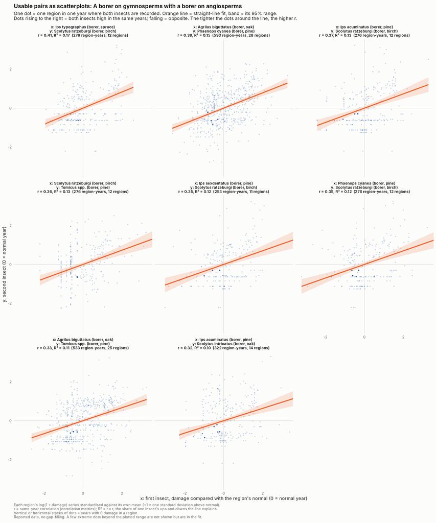

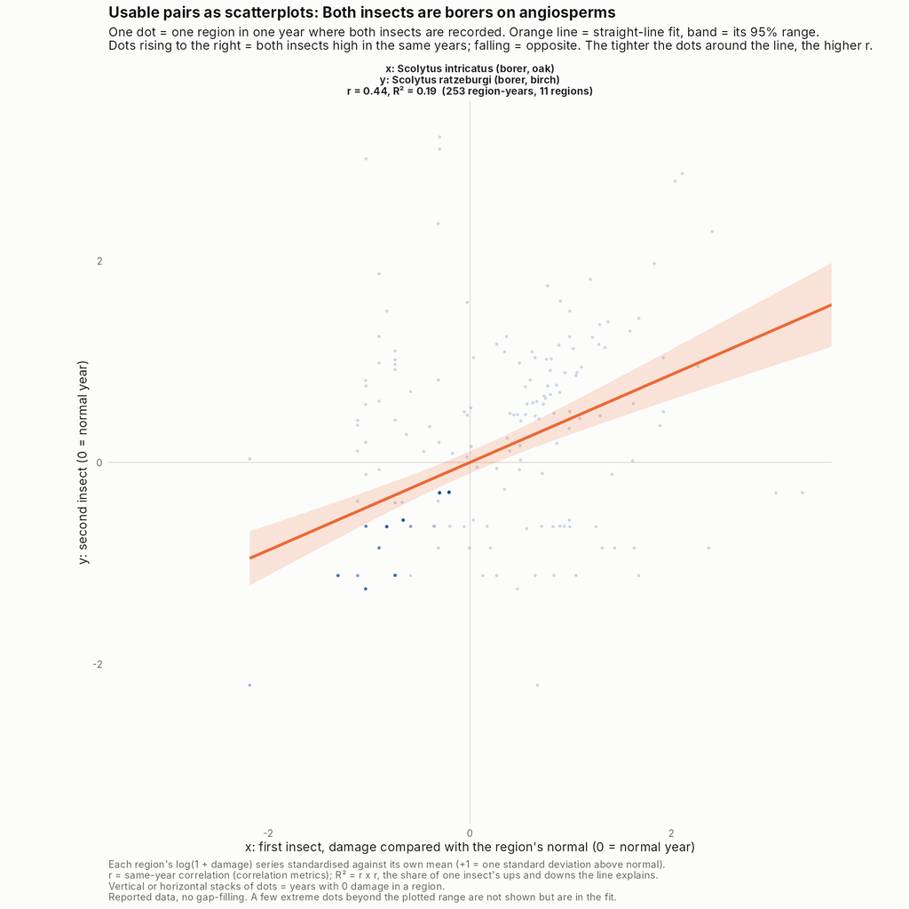

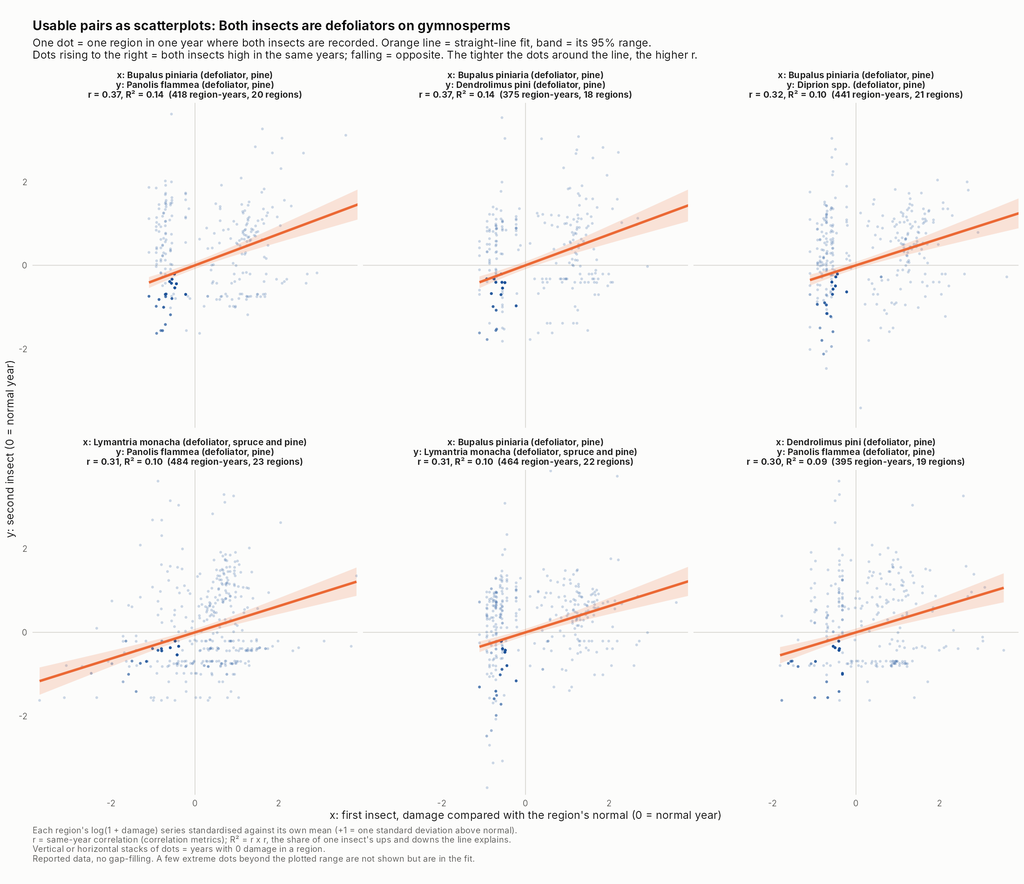

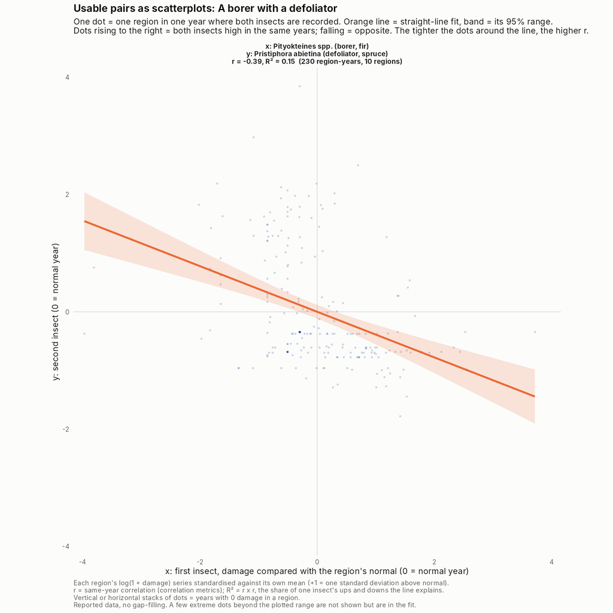

### Predictability across levels of aggregation

Each group pair (the paper’s groups) is compared with the species pairs inside the same two groups. Tested R-squared: each country is predicted by a straight line fitted on the other countries only. Where the group is to the right of its species pairs, grouping predicts better than the single insects it contains. Tables: `outputs/tables/PREDICT_groups_vs_their_species_pairs.csv`, `PREDICT_pairs_all_levels.csv`.

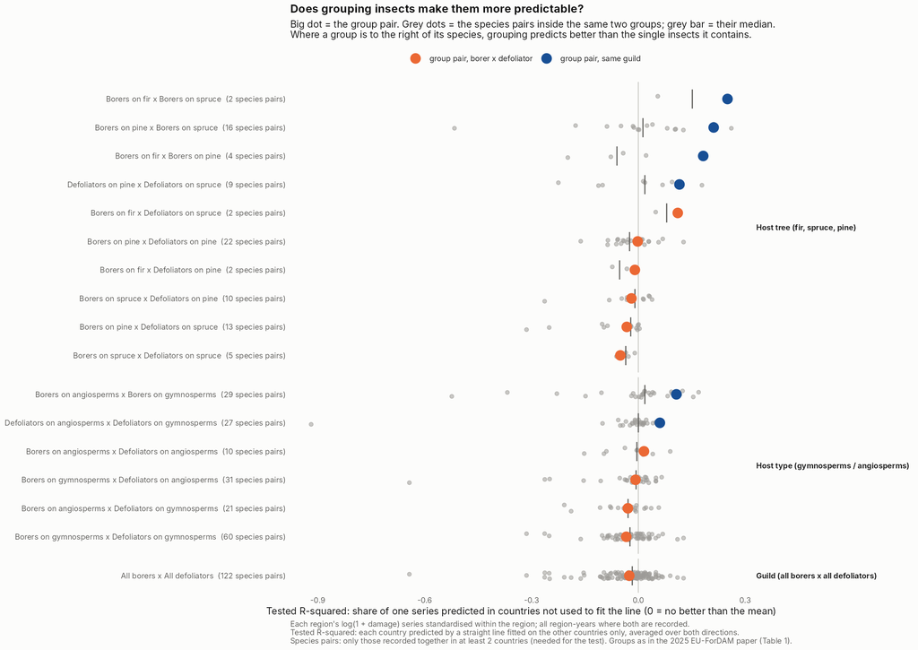

### Broader categories

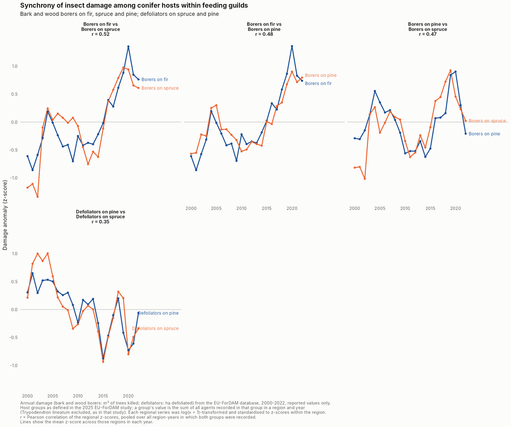

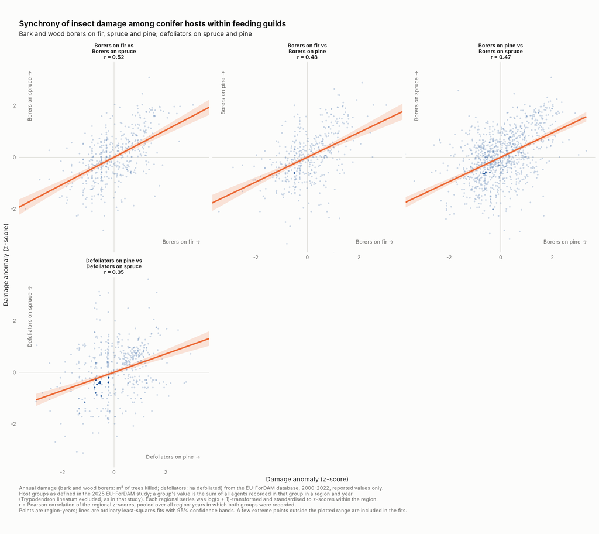

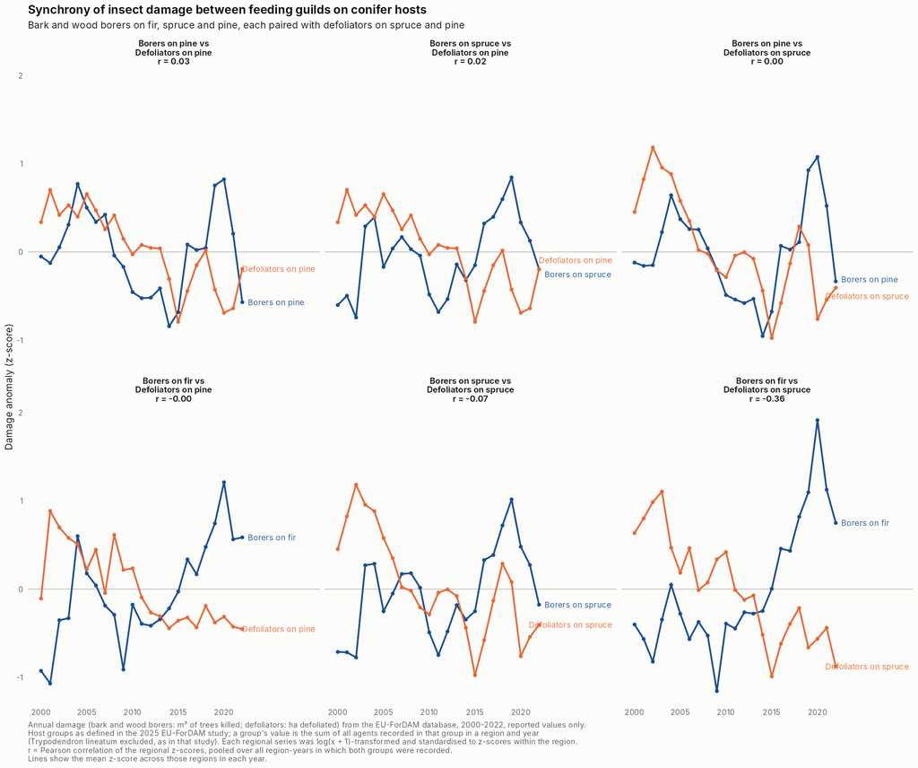

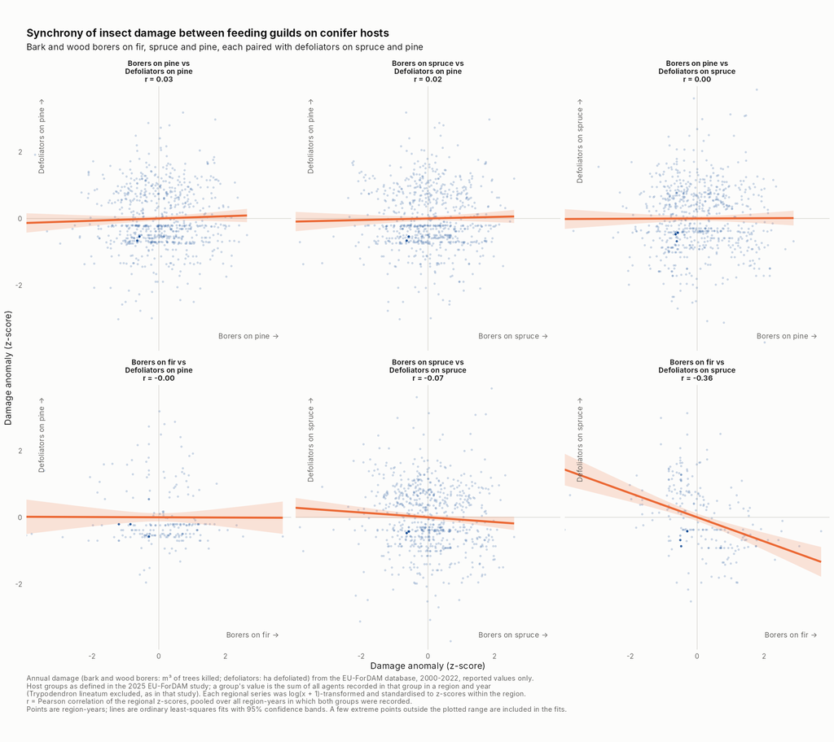